# TD 2 — Régression logistique (R)

Année universitaire 2025–2026 • Parcours Économie de la santé & Développement durable

Régression logistique – traitement de l’exemple vu en cours

Author

Pierre Beaucoral

> Ce TD reprend l’exemple et le dictionnaire de variables (`age, ed, employ, address, income, debtinc, credebt, othdebt, default`) décrits dans la ressource d’origine.  
> Données à récupérer: **`bankloanT.xls`** (ENT).

**Packages utilisés** : `tidyverse`, `readxl`, `janitor`, `broom`, `ResourceSelection`, `pROC`, `gt`, `ggplot2`.

# 1 Rappel de cours : Modèles Logit et Probit

## 1.1 Quand utiliser ces modèles ?

La **régression logistique** et la **régression probit** sont utilisées lorsque la variable à expliquer est **binaire** :

$Y_i \in {0,1}$

- Exemple : défaut de paiement / pas de défaut
- Objectif : estimer la **probabilité** $P(Y_i = 1 \mid X_i)$ en fonction de caractéristiques $X_i$

Les variables explicatives peuvent être **quantitatives ou qualitatives**.

## 1.2 Pourquoi ne pas utiliser une régression linéaire ?

Une régression linéaire classique :

$Y_i = \beta_0 + \beta_1 X_i + \varepsilon_i$

peut donner des valeurs **prédites hors de [0, 1]**, ce qui est absurde pour une probabilité.

Il faut donc introduire une **fonction de lien** qui transforme l’intervalle (0, 1) en $\mathbb{R}$.

## 1.3 Fonction de lien du modèle Logit

$\text{logit}(p) = \ln\left(\frac{p}{1 - p}\right) \quad \text{et} \quad p = \frac{e^{x}}{1 + e^{x}} = \frac{1}{1 + e^{-x}}$

Le modèle s’écrit :

$\text{logit}(P(Y_i = 1)) = \beta_0 + \beta1 X{i1} + \dots + \beta_p X{ip}$

Les coefficients $\beta_j$ s’interprètent via les **odds-ratios** : $OR_j = e^{\beta_j}$

## 1.4 Fonction de lien du modèle Probit

Le modèle Probit suppose qu’il existe une **variable latente** (Y_i^*) telle que :

$Y_i^* = \beta_0 + \beta1 X{i1} + \dots + \beta_p X{ip} + \varepsilon_i \quad \text{avec} \quad \varepsilon_i \sim \mathcal{N}(0,1)$

et on observe :

$Y_i = 1 \text{ si } Y_i^* > 0$

d’où :

$P(Y_i = 1) = \Phi(\beta_0 + \beta_1 X_i)$ où $\Phi$ est la fonction de répartition de la loi normale centrée réduite.

## 1.5 Comparaison graphique des liens Logit et Probit

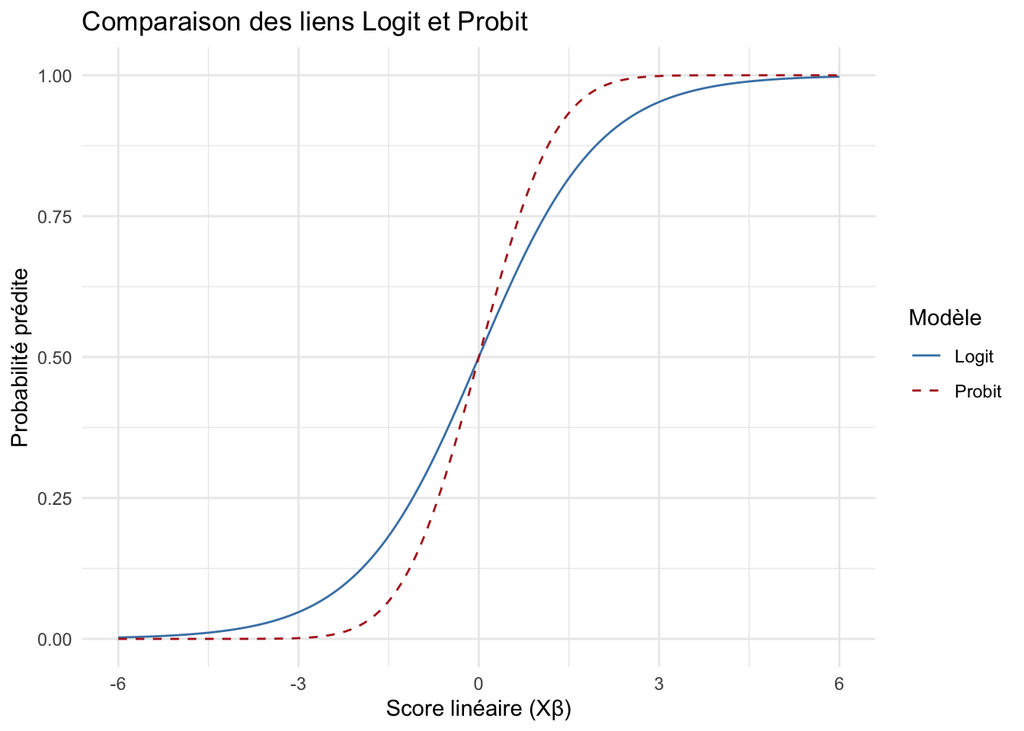

Figure 1: Comparaison des fonctions de lien Logit et Probit

```r
library(ggplot2)

x <- seq(-6, 6, length.out = 200)

df_link <- data.frame( x = x, Logit = 1 / (1 + exp(-x)), Probit = pnorm(x) )

ggplot(df_link, aes(x = x)) + geom_line(aes(y = Logit, color = "Logit")) + geom_line(aes(y = Probit, color = "Probit"), linetype = 2) + scale_color_manual(values = c("Logit" = "steelblue", "Probit" = "firebrick")) + labs( title = "Comparaison des liens Logit et Probit", x = "Score linéaire (Xβ)", y = "Probabilité prédite", color = "Modèle" ) + theme_minimal()
```

### 1.5.1 Interprétation économique

- **Logit** : privilégié quand on interprète les coefficients en termes d’odds-ratios (très courant en santé et sciences sociales).
- **Probit** : privilégié en économie microéconométrique, car il se relie naturellement à un modèle de variable latente et au Tobit.

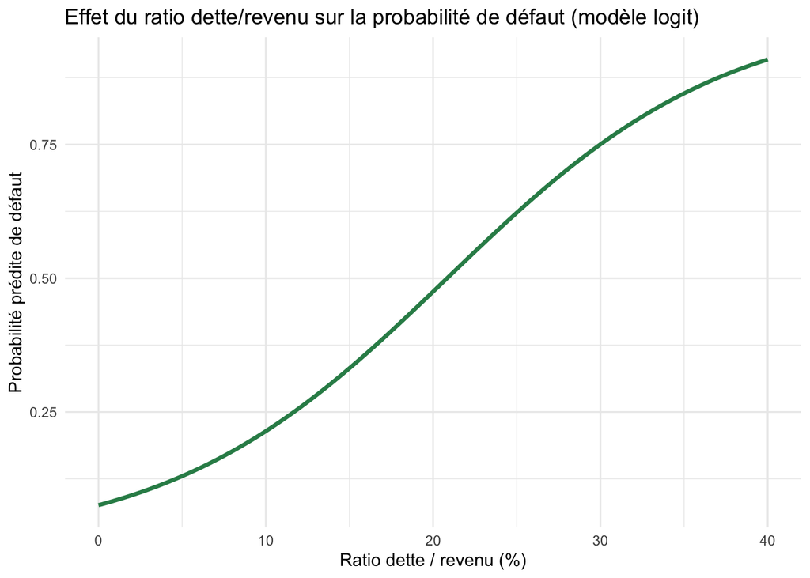

Figure 2: Exemple : probabilité prédite de défaut selon le ratio dette/revenu

```r
x <- seq(0, 40, length.out = 200)
beta0 <- -2.5; beta1 <- 0.12
p_hat <- 1 / (1 + exp(-(beta0 + beta1 * x)))

df_ex <- data.frame(debt_income = x, p_hat = p_hat)

ggplot(df_ex, aes(debt_income, p_hat)) +
geom_line(color = "seagreen4", linewidth = 1.2) +
labs(
title = "Effet du ratio dette/revenu sur la probabilité de défaut (modèle logit)",
x = "Ratio dette / revenu (%)",
y = "Probabilité prédite de défaut"
) +
theme_minimal()
```

**Interprétation :**

→ Lorsque le ratio dette/revenu augmente, la probabilité prédite de défaut croît de manière sigmoïde : faible au départ, elle augmente rapidement autour de la zone moyenne, puis se stabilise.

## 1.6 Résumé comparatif

| Caractéristique | Logit | Probit |
| --- | --- | --- |
| Fonction de lien | logit(p) = log(p/(1−p)) | Φ⁻¹(p) |
| Distribution implicite des erreurs | Logistique | Normale centrée réduite |
| Interprétation des coefficients | Odds-ratios | Z-scores latents |
| Usages typiques | Santé, sociologie | Économie, finance |
| Résultats empiriques | Quasi identiques (β_logit ≈ 1.6 β_probit) |  |

> **À retenir :** Logit et Probit sont deux manières voisines de modéliser une probabilité binaire. Le choix entre les deux est souvent une question de convention disciplinaire ou d’interprétabilité des coefficients.

# 2 Questions TD

## 2.1 Télécharger le fichier bankloanT.xls depuis l’ENT, puis importer les données dans R

```r
df0 <- read_excel("./data/bankloanT.xls") |> clean_names()
df0 |> glimpse()
```

```
Rows: 850
Columns: 9
$ age      <dbl> 44, 26, 47, 31, 33, 45, 45, 35, 38, 32, 36, 47, 34, 39, 27, 4…
$ ed       <chr> "College degree", "High school degree", "Some college", "Did …
$ employ   <dbl> 18, 6, 16, 5, 10, 21, 16, 17, 7, 0, 4, 23, 16, 8, 7, 8, 9, 0,…
$ address  <dbl> 23, 6, 7, 7, 2, 26, 21, 4, 4, 4, 17, 11, 9, 0, 8, 18, 6, 5, 1…
$ income   <dbl> 78, 30, 266, 23, 54, 132, 80, 42, 64, 20, 25, 115, 79, 21, 30…
$ debtinc  <chr> "1", "1", "2", "2", "3", "3", "3", "3", "3", "3", "4", "4", "…
$ creddebt <chr> "0.56472", "0.1437", "2.19184", "0.046", "0.11988", "2.55816"…
$ othdebt  <chr> "0.21528", "0.1563", "3.12816", "0.414", "1.50012", "1.40184"…
$ default  <chr> NA, "No", NA, NA, NA, "No", "No", "No", "No", "Yes", NA, "No"…
```

## 2.2 Etudier la distribution de la variable ed. Créer une variable catégorielle, puis une variable ne contenant que 4 classes.

```r
df0 |> count(ed) |> arrange(desc(n))
```

```
# A tibble: 5 × 2
  ed                               n
  <chr>                        <int>
1 Did not complete high school   460
2 High school degree             235
3 Some college                   101
4 College degree                  49
5 Post-undergraduate degree        5
```

```r
df1 <- df0 |>
  mutate(
    ed5 = factor(ed,
                 levels = c(
                   "Did not complete high school",
                   "High school degree",
                   "Some college",
                   "College degree",
                  "Post-undergraduate degree"
                 ),
                 ordered = TRUE),
    ed4 = fct_collapse(ed5,
                       "College or above" = c("College degree", "Post-undergraduate degree"))
  )

df1 |> count(ed4)
```

```
# A tibble: 4 × 2
  ed4                              n
  <ord>                        <int>
1 Did not complete high school   460
2 High school degree             235
3 Some college                   101
4 College or above                54
```

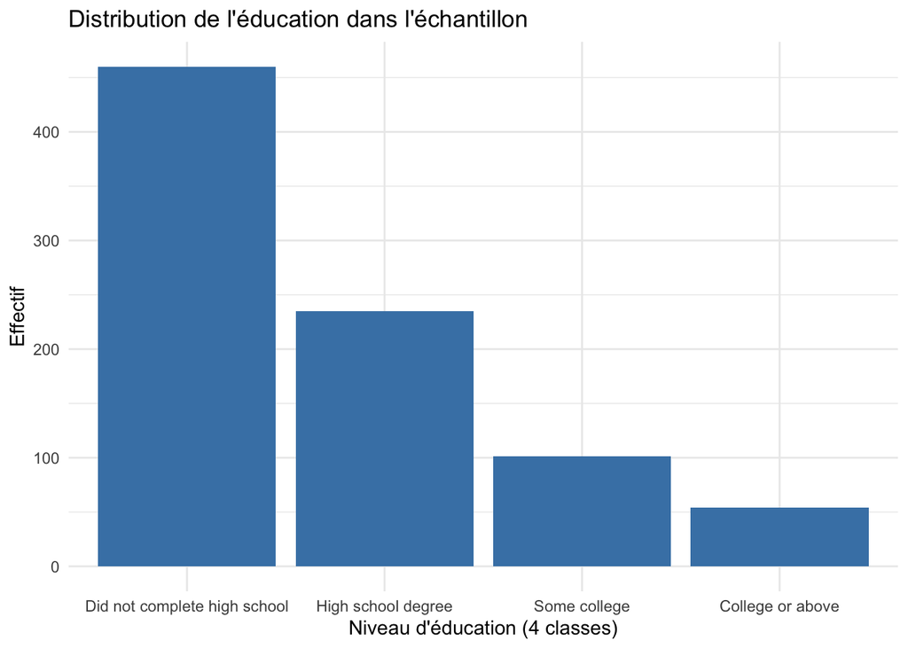

```r
ggplot(df1, aes(x = ed4)) +
  geom_bar(fill = "steelblue") +
  labs(x = "Niveau d'éducation (4 classes)", y = "Effectif",
       title = "Distribution de l'éducation dans l'échantillon") +
  theme_minimal()
```

## 2.3 Etudier la matrice des corrélations entre les 7 variables quantitatives présentes.

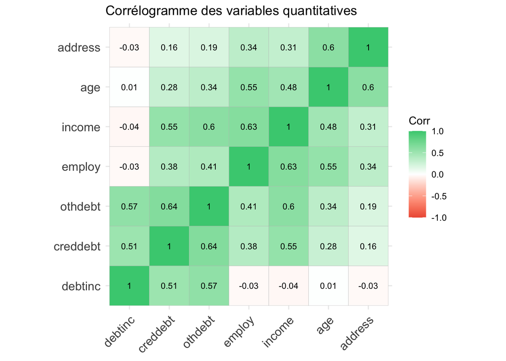

```r
num_vars <- c("age","employ","address","income","debtinc","creddebt","othdebt")
df1 <- df1 |>
  mutate(
    debtinc  = as.numeric(debtinc),
    creddebt = as.numeric(creddebt),
    othdebt  = as.numeric(othdebt)
  )
cor_mat <- df1 |>
  select(all_of(num_vars)) |>
  drop_na() |>
  cor()

library(ggcorrplot)
ggcorrplot(
  cor_mat,
  hc.order = TRUE,           # ordonne les variables par similarité
  lab = TRUE,                # affiche les coefficients
  lab_size = 3,
  colors = c("tomato2", "white", "seagreen3"),
  title = "Corrélogramme des variables quantitatives",
  ggtheme = theme_minimal()
)
```

## 2.4 Recoder la variable à expliquer (default) en variable quantitative puis réaliser une première régression logistique incluant toutes les variables explicatives quantitatives.

```r
df2 <- df1 |>
  mutate(
    default_num = case_when(
      default == "Yes" ~ 1,
      default == "No"  ~ 0,
      TRUE ~ NA_real_   # conserve les NA existants
    )
  )
form1 <- default_num ~ age + employ + address + income + debtinc + creddebt + othdebt
mod1 <- glm(form1, data=df2, family=binomial("logit"))
summary(mod1)
```

```
Call:
glm(formula = form1, family = binomial("logit"), data = df2)

Coefficients:
             Estimate Std. Error z value Pr(>|z|)
(Intercept) -1.377693   0.571585  -2.410   0.0159 *
age          0.033694   0.017341   1.943   0.0520 .
employ      -0.265035   0.031996  -8.283  < 2e-16 ***
address     -0.103964   0.023193  -4.483 7.37e-06 ***
income      -0.007530   0.008099  -0.930   0.3525
debtinc      0.065253   0.030620   2.131   0.0331 *
creddebt     0.628263   0.113738   5.524 3.32e-08 ***
othdebt      0.070289   0.077693   0.905   0.3656
---
Signif. codes:  0 '***' 0.001 '**' 0.01 '*' 0.05 '.' 0.1 ' ' 1

(Dispersion parameter for binomial family taken to be 1)

    Null deviance: 804.36  on 699  degrees of freedom
Residual deviance: 552.21  on 692  degrees of freedom
  (150 observations deleted due to missingness)
AIC: 568.21

Number of Fisher Scoring iterations: 6
```

## 2.5 Réaliser une deuxième régression logistique incluant aussi la variable educ en classe. Enregistrer aussi les résultats de ce modèle, qui est le modèle le plus complexe que nous appliquerons à ces données.

```r
form2 <- update(form1, . ~ . + ed4)
mod2 <- glm(form2, data=df2, family=binomial("logit"))
summary(mod2)
```

```
Call:
glm(formula = form2, family = binomial("logit"), data = df2)

Coefficients:
             Estimate Std. Error z value Pr(>|z|)
(Intercept) -1.469161   0.585721  -2.508   0.0121 *
age          0.036527   0.017564   2.080   0.0376 *
employ      -0.259784   0.033353  -7.789 6.76e-15 ***
address     -0.105959   0.023331  -4.542 5.58e-06 ***
income      -0.007386   0.007927  -0.932   0.3515
debtinc      0.071049   0.030620   2.320   0.0203 *
creddebt     0.616294   0.112296   5.488 4.06e-08 ***
othdebt      0.052860   0.078374   0.674   0.5000
ed4.L        0.003376   0.321415   0.011   0.9916
ed4.Q       -0.334133   0.276144  -1.210   0.2263
ed4.C       -0.030154   0.249875  -0.121   0.9039
---
Signif. codes:  0 '***' 0.001 '**' 0.01 '*' 0.05 '.' 0.1 ' ' 1

(Dispersion parameter for binomial family taken to be 1)

    Null deviance: 804.36  on 699  degrees of freedom
Residual deviance: 550.03  on 689  degrees of freedom
  (150 observations deleted due to missingness)
AIC: 572.03

Number of Fisher Scoring iterations: 6
```

## 2.6 Tester l’ajustement de ce modèle complet, grâce à la commande hoslem.test, où g est le nombre de groupes de niveaux différents de fonction prédictive utilisé pour le test. Varier les valeurs de g pour vérifier la robustesse du résultat.

```r
hoslem.test(mod2$y, fitted(mod2), g=4)
```

```
    Hosmer and Lemeshow goodness of fit (GOF) test

data:  mod2$y, fitted(mod2)
X-squared = 2.3796, df = 2, p-value = 0.3043
```

```r
hoslem.test(mod2$y, fitted(mod2), g=5)
```

```
    Hosmer and Lemeshow goodness of fit (GOF) test

data:  mod2$y, fitted(mod2)
X-squared = 0.9883, df = 3, p-value = 0.8041
```

```r
hoslem.test(mod2$y, fitted(mod2), g=6)
```

```
    Hosmer and Lemeshow goodness of fit (GOF) test

data:  mod2$y, fitted(mod2)
X-squared = 5.3862, df = 4, p-value = 0.2499
```

```r
hoslem.test(mod2$y, fitted(mod2), g=7)
```

```
    Hosmer and Lemeshow goodness of fit (GOF) test

data:  mod2$y, fitted(mod2)
X-squared = 2.0796, df = 5, p-value = 0.838
```

```r
hoslem.test(mod2$y, fitted(mod2), g=8)
```

```
    Hosmer and Lemeshow goodness of fit (GOF) test

data:  mod2$y, fitted(mod2)
X-squared = 3.9178, df = 6, p-value = 0.6878
```

```r
hoslem.test(mod2$y, fitted(mod2), g=9)
```

```
    Hosmer and Lemeshow goodness of fit (GOF) test

data:  mod2$y, fitted(mod2)
X-squared = 5.5538, df = 7, p-value = 0.5927
```

```r
hoslem.test(mod2$y, fitted(mod2), g=10)
```

```
    Hosmer and Lemeshow goodness of fit (GOF) test

data:  mod2$y, fitted(mod2)
X-squared = 5.9712, df = 8, p-value = 0.6505
```

## 2.7 Grâce à la commande anova, réaliser un test de rapport de vraisemblance entre les deux modèles ajustés, et conclure sur la significativité de la variable educ.

```r
anova(mod1, mod2, test="Chisq")
```

```
Analysis of Deviance Table

Model 1: default_num ~ age + employ + address + income + debtinc + creddebt +
    othdebt
Model 2: default_num ~ age + employ + address + income + debtinc + creddebt +
    othdebt + ed4
  Resid. Df Resid. Dev Df Deviance Pr(>Chi)
1       692     552.21
2       689     550.03  3    2.176   0.5367
```

- La p-value = **0.54** → on **ne rejette pas** $H_0$.
- Autrement dit :

  > **l’ajout de la variable d’éducation `ed4` n’améliore pas significativement la qualité du modèle**.

## 2.8 Ôter la variable la moins significative du modèle retenu. Vérifier que la P-value du test

de rapport de vraisemblance entre les modèles avec et sans cette variable est égale ou très proche de la P-value du test bilatéral de nullité du coefficient associé à la variable.

```r
form3 <- update(form1, . ~ . - othdebt)
mod3 <- glm(form3, data=df2, family=binomial("logit"))
summary(mod3)
```

```
Call:
glm(formula = form3, family = binomial("logit"), data = df2)

Coefficients:
             Estimate Std. Error z value Pr(>|z|)
(Intercept) -1.591125   0.522271  -3.047  0.00231 **
age          0.033618   0.017383   1.934  0.05312 .
employ      -0.257986   0.030791  -8.379  < 2e-16 ***
address     -0.103119   0.023141  -4.456 8.34e-06 ***
income      -0.002526   0.006320  -0.400  0.68939
debtinc      0.086173   0.020071   4.293 1.76e-05 ***
creddebt     0.595490   0.104930   5.675 1.39e-08 ***
---
Signif. codes:  0 '***' 0.001 '**' 0.01 '*' 0.05 '.' 0.1 ' ' 1

(Dispersion parameter for binomial family taken to be 1)

    Null deviance: 804.36  on 699  degrees of freedom
Residual deviance: 553.02  on 693  degrees of freedom
  (150 observations deleted due to missingness)
AIC: 567.02

Number of Fisher Scoring iterations: 6
```

```r
anova(mod2, mod3, test="Chisq")
```

```
Analysis of Deviance Table

Model 1: default_num ~ age + employ + address + income + debtinc + creddebt +
    othdebt + ed4
Model 2: default_num ~ age + employ + address + income + debtinc + creddebt
  Resid. Df Resid. Dev Df Deviance Pr(>Chi)
1       689     550.03
2       693     553.02 -4  -2.9856   0.5602
```

## 2.9 Une variable est à nouveau très peu significative. Ajuster un nouveau modèle sans cette variable. Sauvegarder les valeurs prédites par ce modèle.

```r
form4 <- update(form3, . ~ . - income)
mod4 <- glm(form4, data=df2, family=binomial("logit"))
summary(mod4)
```

```
Call:
glm(formula = form4, family = binomial("logit"), data = df2)

Coefficients:
            Estimate Std. Error z value Pr(>|z|)
(Intercept) -1.63128    0.51268  -3.182  0.00146 **
age          0.03256    0.01717   1.896  0.05799 .
employ      -0.26076    0.03011  -8.662  < 2e-16 ***
address     -0.10365    0.02309  -4.490 7.13e-06 ***
debtinc      0.08926    0.01855   4.813 1.49e-06 ***
creddebt     0.57265    0.08723   6.565 5.20e-11 ***
---
Signif. codes:  0 '***' 0.001 '**' 0.01 '*' 0.05 '.' 0.1 ' ' 1

(Dispersion parameter for binomial family taken to be 1)

    Null deviance: 804.36  on 699  degrees of freedom
Residual deviance: 553.18  on 694  degrees of freedom
  (150 observations deleted due to missingness)
AIC: 565.18

Number of Fisher Scoring iterations: 6
```

```r
anova(mod3, mod4, test="Chisq")
```

```
Analysis of Deviance Table

Model 1: default_num ~ age + employ + address + income + debtinc + creddebt
Model 2: default_num ~ age + employ + address + debtinc + creddebt
  Resid. Df Resid. Dev Df Deviance Pr(>Chi)
1       693     553.02
2       694     553.18 -1 -0.15877   0.6903
```

## 2.10 Etablir le tableau de contingence des individus bien ou mal classés avec une règle de coupure à 0,5

```r
# Probabilités prédites
df2_nona <- df2 |> drop_na(age, employ, address, income, debtinc, creddebt, othdebt, default_num, ed4)

p_hat <- predict(mod4, newdata = df2_nona, type = "response")

df2_nona <- df2_nona |>
  mutate(
    p_hat = p_hat,
    pred_class = if_else(p_hat >= 0.5, 1, 0)
  )


table(Predicted = df2_nona$pred_class, Observed = df2_nona$default_num)
```

```
         Observed
Predicted   0   1
        0 476  89
        1  41  94
```

```r
mean(df2_nona$pred_class == df2_nona$default_num, na.rm = TRUE)
```

```
[1] 0.8142857
```

## 2.11 Etablir la courbe ROC pour le « meilleur » modèle, puis calculer les “probabilités prédites” et étudier leur distribution

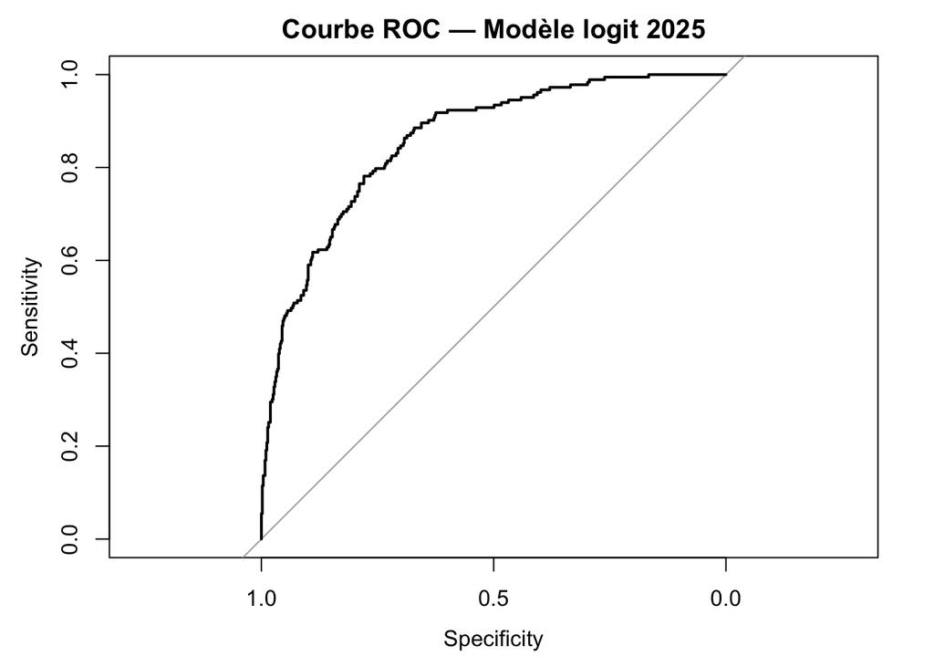

```r
roc_obj <- roc(df2_nona$default_num, df2_nona$p_hat)

plot(roc_obj, main="Courbe ROC — Modèle logit 2025")
```

```r
auc(roc_obj)
```

```
Area under the curve: 0.8582
```

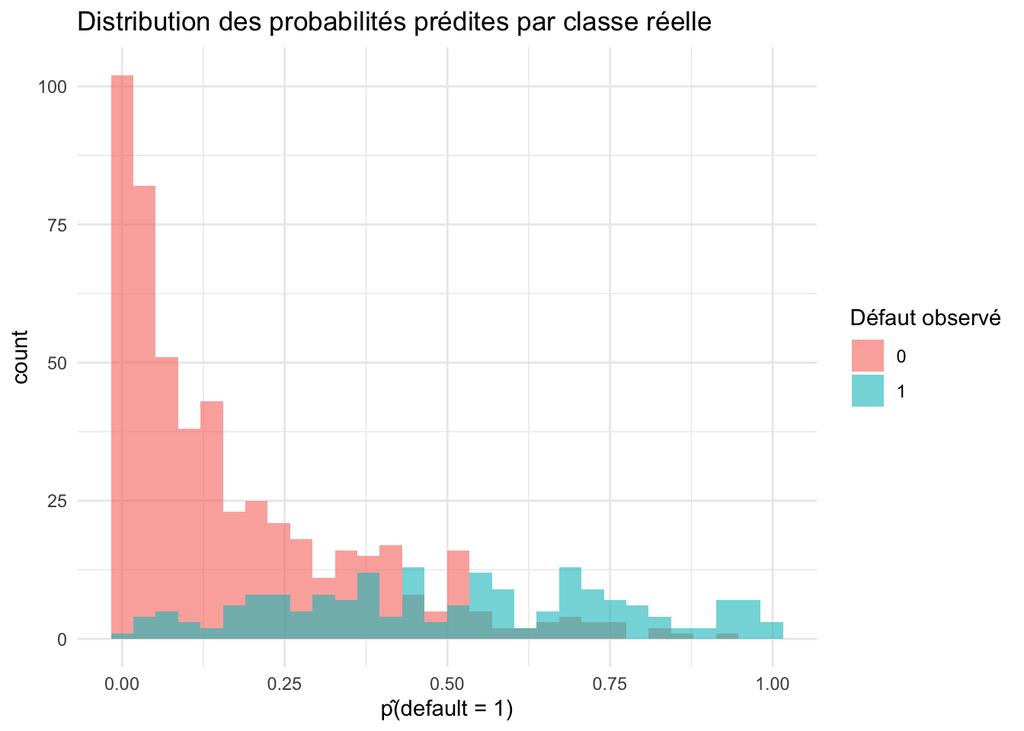

```r
ggplot(df2_nona, aes(x = p_hat, fill = factor(default_num))) +
  geom_histogram(alpha = 0.6, position = "identity", bins = 30) +
  labs(title = "Distribution des probabilités prédites par classe réelle",
       x = "p̂(default = 1)", fill = "Défaut observé") +
  theme_minimal()
```

### 2.11.1 Interprétation du graphe

- L’axe des abscisses montre les **probabilités prédites de défaut** $\hat{p} = P(\text{default}=1|X)$ .
- L’axe des ordonnées montre le **nombre d’individus** dans chaque intervalle de probabilité.
- La couleur rouge (0) représente les **emprunteurs qui n’ont pas fait défaut**.
- La couleur bleue (1) représente les **emprunteurs qui ont fait défaut**.

## 2.12 Refaire la même modélisation avec un modèle Probit et observer les différences et ressemblances avec la modélisation Logit.

```r
mod_probit <- glm(formula(mod4), data=df2, family=binomial("probit"))
summary(mod_probit)
```

```
Call:
glm(formula = formula(mod4), family = binomial("probit"), data = df2)

Coefficients:
             Estimate Std. Error z value Pr(>|z|)
(Intercept) -0.963869   0.297087  -3.244  0.00118 **
age          0.018237   0.009972   1.829  0.06742 .
employ      -0.144955   0.016217  -8.939  < 2e-16 ***
address     -0.055609   0.012835  -4.333 1.47e-05 ***
debtinc      0.051049   0.010563   4.833 1.35e-06 ***
creddebt     0.322172   0.048056   6.704 2.03e-11 ***
---
Signif. codes:  0 '***' 0.001 '**' 0.01 '*' 0.05 '.' 0.1 ' ' 1

(Dispersion parameter for binomial family taken to be 1)

    Null deviance: 804.36  on 699  degrees of freedom
Residual deviance: 554.57  on 694  degrees of freedom
  (150 observations deleted due to missingness)
AIC: 566.57

Number of Fisher Scoring iterations: 6
```

## 2.13 Pour aller plus loin…

Supposant qu’un individu ne remboursant pas son emprunt coûte en moyenne 100000$, et qu’un individu payant son emprunt rapporte en moyenne 40000$, on peut calculer (…) qu’il est optimal de n’accorder un prêt qu’aux individus ayant une probabilité de rembourser estimée à 0,7 ou plus.

## 2.14 Règle de décision (probabilité de remboursement >= 0.7)

```r
df2_nona <- df2_nona |> mutate(p_repay = 1 - p_hat, grant = as.numeric(p_repay >= 0.7))
mean(df2_nona$grant, na.rm = TRUE)
```

```
[1] 0.64
```

## 2.15 Etablir le tableau de contingence des individus bien ou mal classés en considérant comme défaillants potentiels tous les individus ayant moins de 70% de chances de rembourser. Commenter ce tableau.

```r
thr_default <- 0.3
table(Predicted = df2_nona$p_hat >= thr_default, Observed = df2_nona$default_num)
```

```
         Observed
Predicted   0   1
    FALSE 405  43
    TRUE  112 140
```

```r
tab <- table(Predicted = df2_nona$p_hat >= thr_default,
             Observed = df2_nona$default_num)
accuracy <- sum(diag(tab)) / sum(tab)
accuracy
```

```
[1] 0.7785714
```

```r
prop.table(tab, 2)   # pourcentage par classe observée
```

```
         Observed
Predicted         0         1
    FALSE 0.7833656 0.2349727
    TRUE  0.2166344 0.7650273
```

> En fixant le seuil à 0,3 (c’est-à-dire en considérant comme « défaillant potentiel » tout individu ayant moins de 70 % de chances de rembourser), le modèle devient **plus prudent** : il classe davantage d’individus comme risqués. Le nombre de vrais positifs (défaillants correctement détectés) augmente, mais au prix d’une hausse des faux positifs (bons payeurs injustement rejetés).

> Autrement dit, la règle minimise les pertes dues aux impayés, mais réduit le volume de prêts accordés. C’est un **compromis classique entre risque de crédit et rentabilité** :

> Plus le seuil est bas, plus la banque protège son portefeuille, mais plus elle refuse de bons clients.